# Hello woRld

2015-10-28

## With your neighbor, list some things R *is* and *does*

### R is …

### R does …

## R is …

- **Free** to use
- **Extensible**
  - Over 7300 user contributed add-on packages currently on CRAN!
- **Powerful**
  - With the right tools, get more work done, faster.
- **Flexible**
  - Not a question of *can*, but *how*.
- **Frustrating**
  - Flexibility comes at a cost (easy to shoot yourself in the foot!).

## R does …

- **Graphics, statistics, machine learning, etc.**
- **Data acquisition, munging, management**
- **Literate programming (dynamic reports)**
- **Web applications**

(This roughly serves as our outline)

## Some Basics

- Combine values into a vector with `c()`

```r
c(0, 1)
```

```
#> [1] 0 1
```

- Assign values to a name with `<-` (or `=`)

```r
x <- c(0, 1)
```

- Avoid `for` loops and use built-in *vectorized* functions

```r
sum(x + 10)
```

```
#> [1] 21
```

- Although arcane at times, `R` has rich support for documentation, see `?sum`
- Use `[` to extract elements of a vector.

```r
c("a", "b")[1]
```

```
#> [1] "a"
```

```r
c("a", "b")[c(T, F)]
```

```
#> [1] "a"
```

- Extract *named* elements with `$`, `[[`, and/or `[`

```r
x <- list(
  a = 10,
  b = c(1, "2")
)
x$a
```

```
#> [1] 10
```

```r
x[["a"]]
```

```
#> [1] 10
```

```r
x["a"]
```

```
#> $a
#> [1] 10
```

## Examining 'structure'

- `str()` is probably my favorite `R` function. It shows you the "structure" of *any* R object (and *everything* in R is an object!!!)

```r
str(x)
```

```
#> List of 2
#>  $ a: num 10
#>  $ b: chr [1:2] "1" "2"
```

- Lists are heterogenous (elements can have different types)
- Vectors are homogenous (elements have the same type)
  - That's why `c(1, "2")` ends up being a character string.
- If you'd like to know more, see Hadley Wickham's online chapters on [data structures](http://adv-r.had.co.nz/Data-structures.html) and [subsetting](http://adv-r.had.co.nz/Subsetting.html)

## Getting Help

- Reading documentation only gets you so far. What about *finding* function(s) and/or package(s) to help solve a problem???
- Google! (I usually prefix "CRAN" to my search; others might suggest http://www.rseek.org/)
- Ask your question on a relevant StackExchange outlet such as http://stackoverflow.com/ or http://stats.stackexchange.com/
- It's becoming more and more popular to bundle "vignettes" with a package (**dplyr** has *awesome* vignettes)

```r
browseVignettes("dplyr")
```

## Some Oddities

- Yes, `+` is a function (which calls compiled C code)

```r
`+`
```

```
#> function (e1, e2)  .Primitive("+")
```

- What's that? You don't like addition? Me neither!

```r
"+" <- function(x, y) "I forgot how to add"
1 + 2
```

```
#> [1] "I forgot how to add"
```

- But seriously, don't "overload operators" unless you know what you're doing

```r
rm("+")
```

## Trust me

[figure not shown]

## Obligatory economics example

```r
data(economics, package = "ggplot2")
# data frames are essentially a list of vectors
str(economics)
```

```
#> 'data.frame':    478 obs. of  6 variables:
#>  $ date    : Date, format: "1967-06-30" "1967-07-31" ...
#>  $ pce     : num  508 511 517 513 518 ...
#>  $ pop     : int  198712 198911 199113 199311 199498 199657 199808 199920 200056 200208 ...
#>  $ psavert : num  9.8 9.8 9 9.8 9.7 9.4 9 9.5 8.9 9.6 ...
#>  $ uempmed : num  4.5 4.7 4.6 4.9 4.7 4.8 5.1 4.5 4.1 4.6 ...
#>  $ unemploy: int  2944 2945 2958 3143 3066 3018 2878 3001 2877 2709 ...
```

- **Your Turn**: Read the documentation for `economics`. Can you think of a interesting/informative function of these variable(s)?

## Hello ggplot2

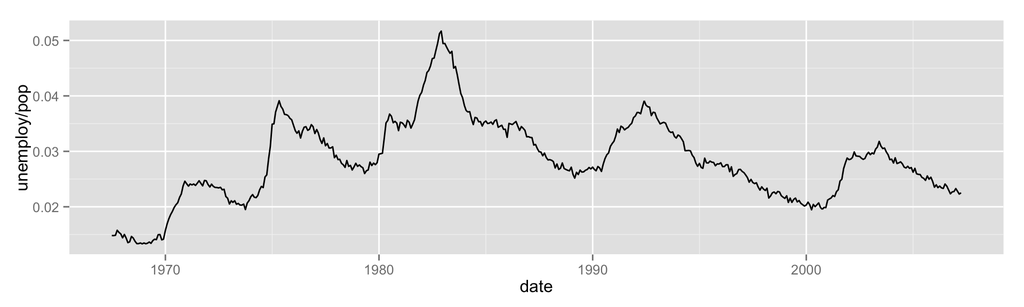

```r
library(ggplot2)
p <- ggplot(economics, aes(date, unemploy / pop)) +
  geom_line()
p
```

## Hello Linear/Additive Models!

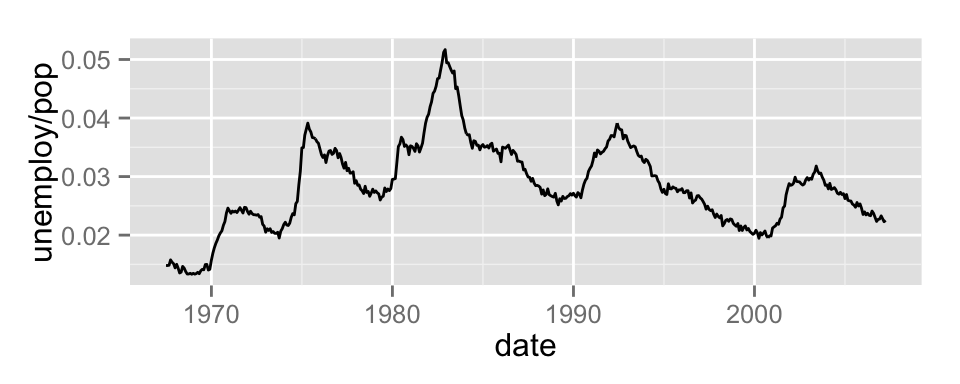

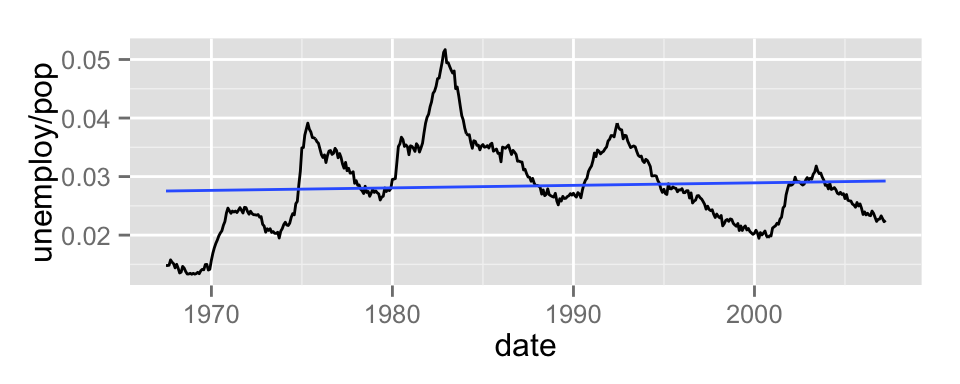

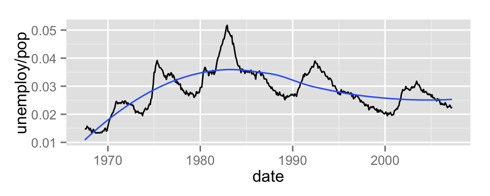

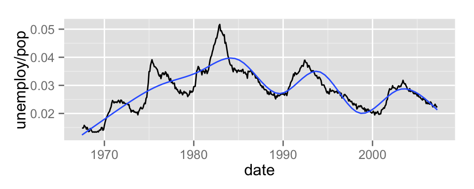

```r
p
p + geom_smooth(method = "lm", se = F)
p + geom_smooth(method = "loess", se = F)
p + geom_smooth(method = "gam", formula = y ~ s(x, bs = "cr"), se = F)
```

## How does `geom_smooth()` work?

```r
m <- lm((unemploy / pop) ~ date, data = economics)
str(m)
```

```
#> List of 12
#>  $ coefficients : Named num [1:2] 2.76e-02 1.17e-07
#>   ..- attr(*, "names")= chr [1:2] "(Intercept)" "date"
#>  $ residuals    : Named num [1:478] -0.0127 -0.0127 -0.0127 -0.0118 -0.0122 ...
#>   ..- attr(*, "names")= chr [1:478] "1" "2" "3" "4" ...
#>  $ effects      : Named num [1:478] -0.6206 0.0108 -0.0113 -0.0104 -0.0108 ...
#>   ..- attr(*, "names")= chr [1:478] "(Intercept)" "date" "" "" ...
#>  $ rank         : int 2
#>  $ fitted.values: Named num [1:478] 0.0275 0.0275 0.0275 0.0275 0.0275 ...
#>   ..- attr(*, "names")= chr [1:478] "1" "2" "3" "4" ...
#>  $ assign       : int [1:2] 0 1
#>  $ qr           :List of 5
#>   ..$ qr   : num [1:478, 1:2] -21.8632 0.0457 0.0457 0.0457 0.0457 ...
#>   .. ..- attr(*, "dimnames")=List of 2
#>   .. .. ..$ : chr [1:478] "1" "2" "3" "4" ...
#>   .. .. ..$ : chr [1:2] "(Intercept)" "date"
#>   .. ..- attr(*, "assign")= int [1:2] 0 1
#>   ..$ qraux: num [1:2] 1.05 1.08
#>   ..$ pivot: int [1:2] 1 2
#>   ..$ tol  : num 1e-07
#>   ..$ rank : int 2
#>   ..- attr(*, "class")= chr "qr"
#>  $ df.residual  : int 476
#>  $ xlevels      : Named list()
#>  $ call         : language lm(formula = (unemploy/pop) ~ date, data = economics)
#>  $ terms        :Classes 'terms', 'formula' length 3 (unemploy/pop) ~ date
#>   .. ..- attr(*, "variables")= language list((unemploy/pop), date)
#>   .. ..- attr(*, "factors")= int [1:2, 1] 0 1
#>   .. .. ..- attr(*, "dimnames")=List of 2
#>   .. .. .. ..$ : chr [1:2] "(unemploy/pop)" "date"
#>   .. .. .. ..$ : chr "date"
#>   .. ..- attr(*, "term.labels")= chr "date"
#>   .. ..- attr(*, "order")= int 1
#>   .. ..- attr(*, "intercept")= int 1
#>   .. ..- attr(*, "response")= int 1
#>   .. ..- attr(*, ".Environment")=<environment: R_GlobalEnv>
#>   .. ..- attr(*, "predvars")= language list((unemploy/pop), date)
#>   .. ..- attr(*, "dataClasses")= Named chr [1:2] "numeric" "other"
#>   .. .. ..- attr(*, "names")= chr [1:2] "(unemploy/pop)" "date"
#>  $ model        :'data.frame':   478 obs. of  2 variables:
#>   ..$ (unemploy/pop): num [1:478] 0.0148 0.0148 0.0149 0.0158 0.0154 ...
#>   ..$ date          : Date[1:478], format: "1967-06-30" ...
#>   ..- attr(*, "terms")=Classes 'terms', 'formula' length 3 (unemploy/pop) ~ date
#>   .. .. ..- attr(*, "variables")= language list((unemploy/pop), date)
#>   .. .. ..- attr(*, "factors")= int [1:2, 1] 0 1
#>   .. .. .. ..- attr(*, "dimnames")=List of 2
#>   .. .. .. .. ..$ : chr [1:2] "(unemploy/pop)" "date"
#>   .. .. .. .. ..$ : chr "date"
#>   .. .. ..- attr(*, "term.labels")= chr "date"
#>   .. .. ..- attr(*, "order")= int 1
#>   .. .. ..- attr(*, "intercept")= int 1
#>   .. .. ..- attr(*, "response")= int 1
#>   .. .. ..- attr(*, ".Environment")=<environment: R_GlobalEnv>
#>   .. .. ..- attr(*, "predvars")= language list((unemploy/pop), date)
#>   .. .. ..- attr(*, "dataClasses")= Named chr [1:2] "numeric" "other"
#>   .. .. .. ..- attr(*, "names")= chr [1:2] "(unemploy/pop)" "date"
#>  - attr(*, "class")= chr "lm"
```

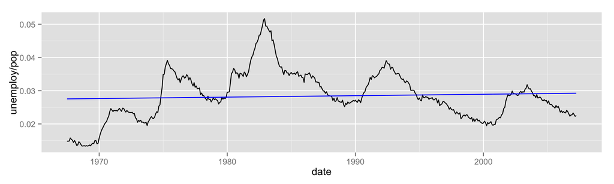

```r
economics$yhat <- m$fitted.values
ggplot(economics) +
  geom_line(aes(date, unemploy / pop)) +
  geom_line(aes(date, yhat), color = "blue")
```

- **Your Turn**: Make the loess smoother plot without `geom_smooth()` (hint: convert `date` to a numeric vector with `as.numeric()` and use `loess()`). For a solution, see [here](https://github.com/cpsievert/slides/blob/gh-pages/intro/yourTurn1.R)

## Time Series Analysis

- `R` has a ton of support for time series analysis (see the [Task View](https://cran.r-project.org/web/views/TimeSeries.html)).
- To create a time series (aka `"ts"`) object, use the `ts()` function

```r
r <- ts(economics$unemploy / economics$pop)
str(r)
```

```
#>  Time-Series [1:478] from 1 to 478: 0.0148 0.0148 0.0149 0.0158 0.0154 ...
```

```r
class(r)
```

```
#> [1] "ts"
```

```r
ar1 <- arima(r, order = c(1, 0, 0))
class(ar1)
```

```
#> [1] "Arima"
```

```r
str(predict(ar1))
```

```
#> List of 2
#>  $ pred: Time-Series [1:1] from 479 to 479: 0.0225
#>  $ se  : Time-Series [1:1] from 479 to 479: 0.000793
```

- From `?predict`:
  - `predict()` is a *generic function* for predictions from the results of various model fitting functions. The function invokes particular *methods* which depend on the class of the first argument.
- Since `class(ar1)` is `"Arima"`, `predict(ar1)` calls `predict.Arima()`.
- Base R comes with a bunch of prediction methods, and add-on packages can easily add new prediction methods for new classes.

```r
methods(predict)
```

```
#>  [1] predict.ar*                predict.Arima*
#>  [3] predict.arima0*            predict.bam
#>  [5] predict.gam                predict.glm
#>  [7] predict.glmmPQL*           predict.gls*
#>  [9] predict.gnls*              predict.HoltWinters*
#> [11] predict.jam*               predict.lda*
#> [13] predict.lm                 predict.lme*
#> [15] predict.lmList*            predict.loess*
#> [17] predict.lqs*               predict.mca*
#> [19] predict.mlm*               predict.nlme*
#> [21] predict.nls*               predict.polr*
#> [23] predict.poly*              predict.ppr*
#> [25] predict.prcomp*            predict.princomp*
#> [27] predict.qda*               predict.rlm*
#> [29] predict.smooth.spline*     predict.smooth.spline.fit*
#> [31] predict.StructTS*
#> see '?methods' for accessing help and source code
```

`summary()` is another useful generic function. Turns out `summary.Arima()` doesn't exist in base `R`, but the **forecast** package provides one for us %^)

```r
library(forecast)
summary(ar1)
```

```
#>
#> Call:
#> arima(x = r, order = c(1, 0, 0))
#>
#> Coefficients:
#>          ar1  intercept
#>       0.9950     0.0247
#> s.e.  0.0038     0.0054
#>
#> sigma^2 estimated as 6.288e-07:  log likelihood = 2732.23,  aic = -5458.45
#>
#> Training set error measures:
#>                        ME        RMSE          MAE        MPE     MAPE
#> Training set 3.285495e-05 0.000792985 0.0006000848 0.06766484 2.159303
#>                   MASE      ACF1
#> Training set 0.9984496 0.1249286
```

```r
methods(summary)
```

```
#>  [1] summary,ANY-method             summary,diagonalMatrix-method
#>  [3] summary,sparseMatrix-method    summary.aov
#>  [5] summary.aovlist*               summary.Arima*
#>  [7] summary.arma*                  summary.aspell*
#>  [9] summary.check_packages_in_dir* summary.connection
#> [11] summary.corAR1*                summary.corARMA*
#> [13] summary.corCAR1*               summary.corCompSymm*
#> [15] summary.corExp*                summary.corGaus*
#> [17] summary.corIdent*              summary.corLin*
#> [19] summary.corNatural*            summary.corRatio*
#> [21] summary.corSpher*              summary.corStruct*
#> [23] summary.corSymm*               summary.data.frame
#> [25] summary.Date                   summary.default
#> [27] summary.ecdf*                  summary.ets*
#> [29] summary.factor                 summary.forecast*
```

[output cut: 32 more lines]

**Your Turn**:

- Have a look over `?predict` and `?predict.Arima`. Forecast 10 steps ahead using the `ar1` model. See [here](https://github.com/cpsievert/slides/blob/gh-pages/intro/yourTurn2.R) for a solution.
- Have a look over `?forecast` and `?forecast.Arima`. How is `predict.Arima()` different from `forecast.Arima()`?
- **Warning**: Solution is on the next page, are you sure you want to continue?

The `forecast()` function in the **forecast** package makes it easy to construct and plot prediction intervals.

```r
forecast(ar1, level = 95)
```

```
#>     Point Forecast      Lo 95      Hi 95
#> 479     0.02253712 0.02098290 0.02409134
#> 480     0.02254782 0.02035535 0.02474030
#> 481     0.02255848 0.01988000 0.02523695
#> 482     0.02256908 0.01948399 0.02565416
#> 483     0.02257962 0.01913903 0.02602022
#> 484     0.02259011 0.01883055 0.02634968
#> 485     0.02260055 0.01854989 0.02665122
#> 486     0.02261094 0.01829138 0.02693050
#> 487     0.02262128 0.01805108 0.02719147
#> 488     0.02263156 0.01782610 0.02743701
```

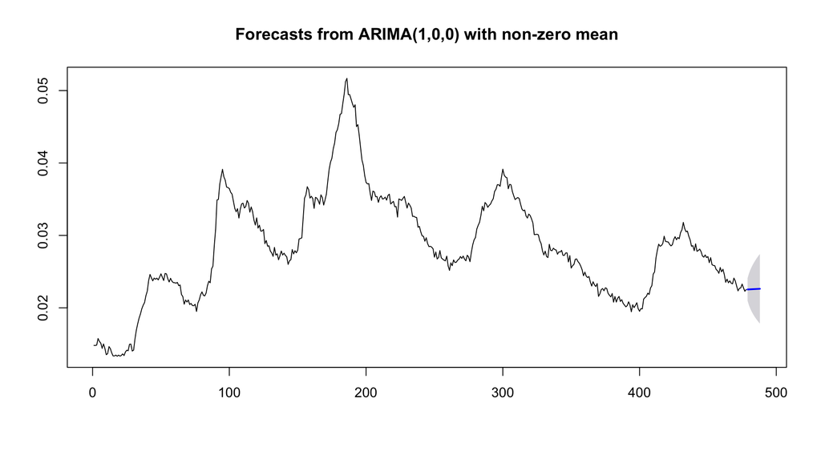

```r
plot(forecast(ar1, level = 95))
```

**Your Turn**: Can you reconstruct `plot(forecast(ar1, level = 95))` using **ggplot2**? Here are some hints:

- `as.data.frame(forecast(ar1, level = 95))` gives you the forecast data. Modify the column names so they don't have spaces (see `?names`).
- You'll need the corresponding forecast dates. See `?seq.Date` for creating a sequence of dates.
- `geom_ribbon()` is helpful for plotting the uncertainty.

See [here](https://gist.github.com/cpsievert/62d6f5ddcdb923324e2a) for a solution

```r
# to run the your turn solution...
devtools::source_gist("62d6f5ddcdb923324e2a")
```

## Interactive and web-based!

```r
library(plotly)
ggplotly(p)
```

[interactive chart not shown]

## Reshaping data

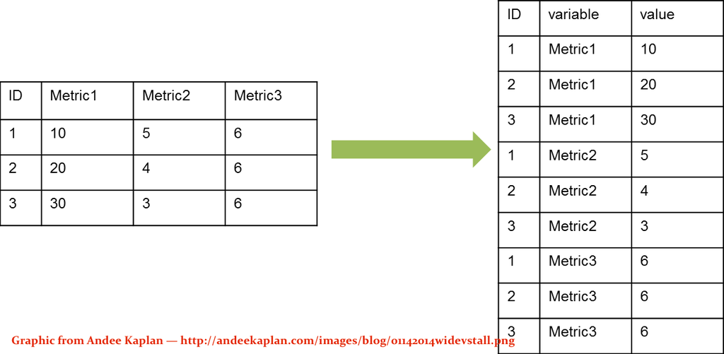

```r
head(economics)
```

```
#>         date   pce    pop psavert uempmed unemploy
#> 1 1967-06-30 507.8 198712     9.8     4.5     2944
#> 2 1967-07-31 510.9 198911     9.8     4.7     2945
#> 3 1967-08-31 516.7 199113     9.0     4.6     2958
#> 4 1967-09-30 513.3 199311     9.8     4.9     3143
#> 5 1967-10-31 518.5 199498     9.7     4.7     3066
#> 6 1967-11-30 526.2 199657     9.4     4.8     3018
```

```r
library(tidyr)
e <- gather(economics, variable, value, -date)
head(e)
```

```
#>         date variable value
#> 1 1967-06-30      pce 507.8
#> 2 1967-07-31      pce 510.9
#> 3 1967-08-31      pce 516.7
#> 4 1967-09-30      pce 513.3
#> 5 1967-10-31      pce 518.5
#> 6 1967-11-30      pce 526.2
```

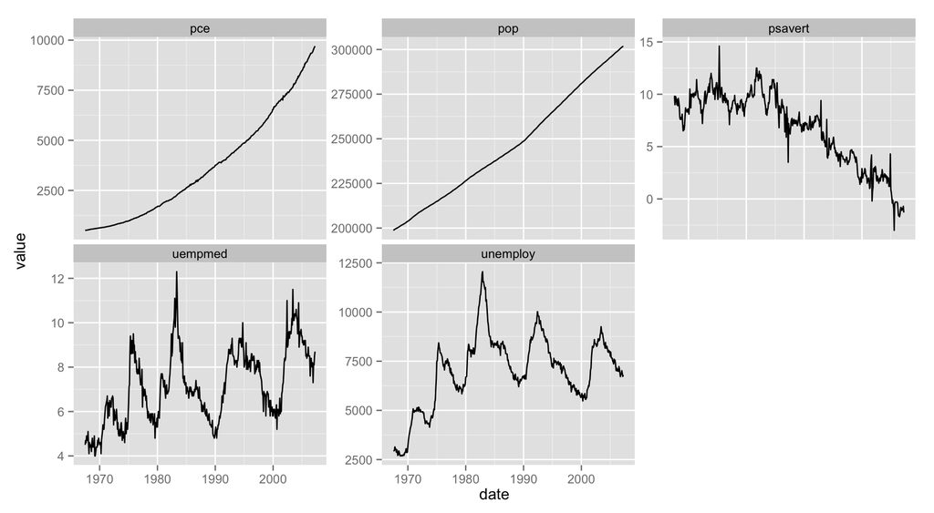

```r
ggplot(e, aes(date, value)) + geom_line() +
  facet_wrap(~ variable, scales = "free_y")
```

## Pure functional programming

Pure functions *modify* a central object-type (e.g., input a data frame and output another data frame)

**Your turn**: Have we encountered any 'pure' function(s)? Can you think of any other pure functions?

## Pure functions in base R

```r
subset(
  transform(
    economics,
    year = format(date, "%Y")
  ),
  year == 2000
)
```

```
#>           date    pce    pop psavert uempmed unemploy year
#> 392 2000-01-31 6618.5 281190     2.4     6.1     5858 2000
#> 393 2000-02-29 6685.3 281409     2.0     6.0     5733 2000
#> 394 2000-03-31 6664.2 281653     2.4     6.1     5481 2000
#> 395 2000-04-30 6688.0 281891     2.4     5.8     5758 2000
#> 396 2000-05-31 6712.1 282156     2.5     5.7     5651 2000
#> 397 2000-06-30 6745.8 282430     2.9     6.0     5747 2000
#> 398 2000-07-31 6766.7 282706     2.8     6.3     5853 2000
#> 399 2000-08-31 6839.3 282994     2.2     5.2     5625 2000
#> 400 2000-09-30 6846.2 283271     2.3     6.1     5534 2000
#> 401 2000-10-31 6860.2 283531     2.1     6.1     5639 2000
#> 402 2000-11-30 6908.5 283782     1.5     6.0     5634 2000
#> 403 2000-12-31 6938.2 284015     1.9     5.8     6023 2000
```

[figure not shown]

**magrittr's** `%>%` operator makes it much easier to read a sequence of pure manipulations

```r
library(magrittr)
economics %>%
  transform(year = format(date, "%Y")) %>%
  subset(year == 2000)
```

```r
# in general, this:
f(g(x), y)
# equal this
x %>% g() %>% f(y)
```

- `%>%` allows us to read left -> right (instead of inside -> out)

## dplyr: A consistent grammar of data manipulation

```r
library(dplyr)
economics %>%
  mutate(year = format(date, "%Y")) %>%
  filter(year == 2000)
```

```
#>          date    pce    pop psavert uempmed unemploy year
#> 1  2000-01-31 6618.5 281190     2.4     6.1     5858 2000
#> 2  2000-02-29 6685.3 281409     2.0     6.0     5733 2000
#> 3  2000-03-31 6664.2 281653     2.4     6.1     5481 2000
#> 4  2000-04-30 6688.0 281891     2.4     5.8     5758 2000
#> 5  2000-05-31 6712.1 282156     2.5     5.7     5651 2000
#> 6  2000-06-30 6745.8 282430     2.9     6.0     5747 2000
#> 7  2000-07-31 6766.7 282706     2.8     6.3     5853 2000
#> 8  2000-08-31 6839.3 282994     2.2     5.2     5625 2000
#> 9  2000-09-30 6846.2 283271     2.3     6.1     5534 2000
#> 10 2000-10-31 6860.2 283531     2.1     6.1     5639 2000
#> 11 2000-11-30 6908.5 283782     1.5     6.0     5634 2000
#> 12 2000-12-31 6938.2 284015     1.9     5.8     6023 2000
```

## Split-apply-combine

[figure not shown]

Image by Karthik Ram -> http://inundata.org/R_talks/meetup/images/splitapply.png

## Split-apply-combine in dplyr

```r
economics %>%
  mutate(year = format(date, "%Y")) %>%
  group_by(year) %>%
  summarise(mpce = mean(pce))
```

```
#> Source: local data frame [41 x 2]
#>
#>     year      mpce
#>    (chr)     (dbl)
#> 1   1967  517.9143
#> 2   1968  562.4417
#> 3   1969  609.0000
#> 4   1970  652.4333
#> 5   1971  706.5083
#> 6   1972  777.7250
#> 7   1973  858.1417
#> 8   1974  941.0167
#> 9   1975 1045.3833
#> 10  1976 1160.9333
#> ..   ...       ...
```

## Your Turn

Find the average annual personal savings rate (`psavert`)

```r
economics %>%
  mutate(year = format(date, "%Y")) %>%
  group_by(year) %>%
  summarise(mpce = mean(psavert))
```

```
#> Source: local data frame [41 x 2]
#>
#>     year      mpce
#>    (chr)     (dbl)
#> 1   1967  9.500000
#> 2   1968  8.316667
#> 3   1969  7.866667
#> 4   1970  9.575000
#> 5   1971  9.975000
#> 6   1972  8.858333
#> 7   1973 10.683333
#> 8   1974 10.491667
#> 9   1975 10.475000
#> 10  1976  9.341667
#> ..   ...       ...
```

## A new example: babynames

```r
library(babynames)
head(babynames)
```

```
#> Source: local data frame [6 x 5]
#>
#>    year   sex      name     n       prop
#>   (dbl) (chr)     (chr) (int)      (dbl)
#> 1  1880     F      Mary  7065 0.07238359
#> 2  1880     F      Anna  2604 0.02667896
#> 3  1880     F      Emma  2003 0.02052149
#> 4  1880     F Elizabeth  1939 0.01986579
#> 5  1880     F    Minnie  1746 0.01788843
#> 6  1880     F  Margaret  1578 0.01616720
```

```r
dim(babynames)
```

```
#> [1] 1792091       5
```

## Write/read csv (or other flat files)

```r
library(readr)
bb_path <- tempfile(fileext = ".csv")
write_csv(babynames, bb_path)
read_csv(bb_path)
```

```
#> Source: local data frame [1,792,091 x 5]
#>
#>     year   sex      name     n       prop
#>    (int) (chr)     (chr) (int)      (dbl)
#> 1   1880     F      Mary  7065 0.07238359
#> 2   1880     F      Anna  2604 0.02667896
#> 3   1880     F      Emma  2003 0.02052149
#> 4   1880     F Elizabeth  1939 0.01986579
#> 5   1880     F    Minnie  1746 0.01788843
#> 6   1880     F  Margaret  1578 0.01616720
#> 7   1880     F       Ida  1472 0.01508119
#> 8   1880     F     Alice  1414 0.01448696
#> 9   1880     F    Bertha  1320 0.01352390
#> 10  1880     F     Sarah  1288 0.01319605
#> ..   ...   ...       ...   ...        ...
```

## Get other formats into R

```r
library(readxl)
read_excel("my-spreadsheet.xls", sheet = "data")
read_excel("my-spreadsheet.xls", sheet = 2)
```

```r
library(haven)
# SAS files
read_sas("path/to/file")
# SPSS files
read_por("path/to/file")
read_sav("path/to/file")
# Stata files
read_dta("path/to/file")
```

## dplyr loves databases

```r
db <- src_sqlite("intro/babynames.sqlite3", create = TRUE)
copy_to(db, babynames, temporary = FALSE)
```

```r
db
```

```
#> src:  sqlite 3.8.6 [babynames.sqlite3]
#> tbls: babynames, sqlite_stat1
```

```r
tbl(db, "babynames")
```

```
#> Source: sqlite 3.8.6 [babynames.sqlite3]
#> From: babynames [1,792,091 x 5]
#>
#>     year   sex      name     n       prop
#>    (dbl) (chr)     (chr) (int)      (dbl)
#> 1   1880     F      Mary  7065 0.07238359
#> 2   1880     F      Anna  2604 0.02667896
#> 3   1880     F      Emma  2003 0.02052149
#> 4   1880     F Elizabeth  1939 0.01986579
#> 5   1880     F    Minnie  1746 0.01788843
#> 6   1880     F  Margaret  1578 0.01616720
#> 7   1880     F       Ida  1472 0.01508119
#> 8   1880     F     Alice  1414 0.01448696
#> 9   1880     F    Bertha  1320 0.01352390
#> 10  1880     F     Sarah  1288 0.01319605
#> ..   ...   ...       ...   ...        ...
```

## Send computation to the data

```r
h <- db %>%
  tbl("babynames") %>%
  filter(name == "Hilary")
```

```r
class(h)
```

```
#> [1] "tbl_sqlite" "tbl_sql"    "tbl"
```

```r
h$query
```

```
#> <Query> SELECT "year", "sex", "name", "n", "prop"
#> FROM "babynames"
#> WHERE "name" = 'Hilary'
#> <SQLiteConnection>
```

```r
# execute SQL query and bring into R
hc <- collect(h)
class(hc)
```

```
#> [1] "tbl_df"     "tbl"        "data.frame"
```

```r
hc
```

```
#> Source: local data frame [189 x 5]
#>
#>     year   sex   name     n         prop
#>    (dbl) (chr)  (chr) (int)        (dbl)
#> 1   1882     M Hilary     7 5.736200e-05
#> 2   1883     M Hilary     6 5.334234e-05
#> 3   1887     M Hilary     7 6.403571e-05
#> 4   1891     M Hilary     8 7.321247e-05
#> 5   1896     M Hilary     6 4.648388e-05
#> 6   1897     M Hilary     5 4.100276e-05
#> 7   1898     M Hilary     5 3.784782e-05
#> 8   1902     M Hilary     8 6.026411e-05
#> 9   1904     M Hilary     5 3.609900e-05
#> 10  1905     M Hilary     6 4.188628e-05
#> ..   ...   ...    ...   ...          ...
```

```r
plot_ly(hc, x = year, y = prop, color = sex, colors = c("blue", "hotpink"))
```

[interactive chart not shown]

```r
popular <- babynames %>%
  group_by(name) %>%
  summarise(N = sum(n)) %>%
  arrange(desc(N))
popular
```

```
#> Source: local data frame [92,600 x 2]
#>
#>       name       N
#>      (chr)   (int)
#> 1    James 5114325
#> 2     John 5095590
#> 3   Robert 4809858
#> 4  Michael 4315029
#> 5     Mary 4127615
#> 6  William 4054318
#> 7    David 3578068
#> 8   Joseph 2568379
#> 9  Richard 2561839
#> 10 Charles 2369238
#> ..     ...     ...
```

```r
top <- top_n(popular, 1000)
topnames <- subset(babynames, name %in% top[["name"]])
topnames
```

```
#> Source: local data frame [177,224 x 5]
#>
#>     year   sex      name     n       prop
#>    (dbl) (chr)     (chr) (int)      (dbl)
#> 1   1880     F      Mary  7065 0.07238359
#> 2   1880     F      Anna  2604 0.02667896
#> 3   1880     F      Emma  2003 0.02052149
#> 4   1880     F Elizabeth  1939 0.01986579
#> 5   1880     F    Minnie  1746 0.01788843
#> 6   1880     F  Margaret  1578 0.01616720
#> 7   1880     F       Ida  1472 0.01508119
#> 8   1880     F     Alice  1414 0.01448696
#> 9   1880     F    Bertha  1320 0.01352390
#> 10  1880     F     Sarah  1288 0.01319605
#> ..   ...   ...       ...   ...        ...
```

[interactive chart not shown]

```r
library(shiny)
library(ggplot2)
ui <- bootstrapPage(
  selectizeInput(
    inputId = 'name',
    label = 'Enter a name',
    choices = unique(topnames$name),
    selected = "James",
    multiple = TRUE
  ),
  plotOutput('plot')
)
server <- function(input, output) {
  output$plot <- renderPlot({
    dat <- subset(topnames, name %in% input$name)
    ggplot(dat, aes(year, prop, colour = sex)) +
      geom_line() + facet_wrap(~ name)
  })
}
runApp(shinyApp(ui, server))
```

## Thanks for coming!

- Find me in Menzies E775
- https://github.com/cpsievert
- https://twitter.com/cpsievert